# Определение стоимости автомобилей

# Содержание

**Цели исследования:**

По историческим данным (техническим характеристикам, комплектации и ценам автомобилей) построить для заказчика модель определения стоимости автомобиля для использовании в приложении сервиса по продаже автомобилей с пробегом «Не бит, не крашен».

Заказчику важны:

- качество предсказания;
- скорость предсказания;
- время обучения.

Следует обучить и подобрать модель с лучшими результатами по этим характеристикам.

**Ход исследования:**

- Подготовка данных
  - Загрузка и знакомство с данными
  - Предобработка данных
- Обучение моделей для предсказания цены автомобилей
- Анализ моделей по параметрам качества, скорости и времени обучения
- Итоговый вывод

**Результаты исследования:**

- Построены и протестированы несколько моделей машинного обучения: Линейная регрессия, Случайный лес, Градиентный бустинг (CatBoost и LightGBM).
- По критериям качества предсказания (`(val) RMSE`); скорости предсказания (`Inference time`); времени обучения (`Training time`) была сведена рейтинговая таблица моделей, по которой клиент может посчитать рейтинг нужной ему модели сообразно весам, которые он присвоит критериям. Клиенту был предоставлен механизм оценки обученных моделей на основе вектора его предпочтений.
- Клиенту, чьи предпочтения описываются вектором весов, предлагается для определения стоимости автомобиля по историческим данным выбрать модель с наивысшим рейтингом.

## Подготовка данных

### Описание данных

**Признаки**

```
DateCrawled — дата скачивания анкеты из базы
VehicleType — тип автомобильного кузова
RegistrationYear — год регистрации автомобиля
Gearbox — тип коробки передач
Power — мощность (л. с.)
Model — модель автомобиля
Kilometer — пробег (км)
RegistrationMonth — месяц регистрации автомобиля
FuelType — тип топлива
Brand — марка автомобиля
NotRepaired — была машина в ремонте или нет
DateCreated — дата создания анкеты
NumberOfPictures — количество фотографий автомобиля
PostalCode — почтовый индекс владельца анкеты (пользователя)
LastSeen — дата последней активности пользователя
```

**Целевой признак**

Price — цена (евро)

### Загрузка библиотек

```python
import pandas as pd
import numpy as np
import matplotlib.pyplot as plt

from sklearn.model_selection import cross_val_score, RandomizedSearchCV, train_test_split
from sklearn.metrics import mean_squared_error
from sklearn.preprocessing import StandardScaler, PolynomialFeatures, OneHotEncoder, OrdinalEncoder

from sklearn.ensemble import RandomForestRegressor
from sklearn.linear_model import LinearRegression

from catboost import CatBoostRegressor
from lightgbm import LGBMRegressor

from time import time
```

### Загрузка и знакомство с данными

```python
autos = pd.read_csv('/home/panther/Documents/Deep Learning/datasets/autos.csv')
```

```python
autos.head()
```

|  | DateCrawled | Price | VehicleType | RegistrationYear | Gearbox | Power | Model | Kilometer | RegistrationMonth | FuelType | Brand | Repaired | DateCreated | NumberOfPictures | PostalCode | LastSeen |
| --- | --- | --- | --- | --- | --- | --- | --- | --- | --- | --- | --- | --- | --- | --- | --- | --- |
| 0 | 2016-03-24 11:52:17 | 480 | NaN | 1993 | manual | 0 | golf | 150000 | 0 | petrol | volkswagen | NaN | 2016-03-24 00:00:00 | 0 | 70435 | 2016-04-07 03:16:57 |
| 1 | 2016-03-24 10:58:45 | 18300 | coupe | 2011 | manual | 190 | NaN | 125000 | 5 | gasoline | audi | yes | 2016-03-24 00:00:00 | 0 | 66954 | 2016-04-07 01:46:50 |
| 2 | 2016-03-14 12:52:21 | 9800 | suv | 2004 | auto | 163 | grand | 125000 | 8 | gasoline | jeep | NaN | 2016-03-14 00:00:00 | 0 | 90480 | 2016-04-05 12:47:46 |
| 3 | 2016-03-17 16:54:04 | 1500 | small | 2001 | manual | 75 | golf | 150000 | 6 | petrol | volkswagen | no | 2016-03-17 00:00:00 | 0 | 91074 | 2016-03-17 17:40:17 |
| 4 | 2016-03-31 17:25:20 | 3600 | small | 2008 | manual | 69 | fabia | 90000 | 7 | gasoline | skoda | no | 2016-03-31 00:00:00 | 0 | 60437 | 2016-04-06 10:17:21 |

Выясняю дату последнего объявления:

```python
pd.to_datetime(autos['DateCreated']).max()
```

```
Timestamp('2016-04-07 00:00:00')
```

```python
autos.info()
```

```
<class 'pandas.core.frame.DataFrame'>
RangeIndex: 354369 entries, 0 to 354368
Data columns (total 16 columns):
 #   Column             Non-Null Count   Dtype
---  ------             --------------   -----
 0   DateCrawled        354369 non-null  object
 1   Price              354369 non-null  int64
 2   VehicleType        316879 non-null  object
 3   RegistrationYear   354369 non-null  int64
 4   Gearbox            334536 non-null  object
 5   Power              354369 non-null  int64
 6   Model              334664 non-null  object
 7   Kilometer          354369 non-null  int64
 8   RegistrationMonth  354369 non-null  int64
 9   FuelType           321474 non-null  object
 10  Brand              354369 non-null  object
 11  Repaired           283215 non-null  object
 12  DateCreated        354369 non-null  object
 13  NumberOfPictures   354369 non-null  int64
 14  PostalCode         354369 non-null  int64
 15  LastSeen           354369 non-null  object
dtypes: int64(7), object(9)
memory usage: 43.3+ MB
```

Проверка на дубликаты:

```python
autos.duplicated().sum()
```

```
4
```

```python
autos = autos.drop_duplicates()
autos.duplicated().sum()
```

```
0
```

Удаление ненужных признаков (дублирующих информацию или бесполезных):

```python
autos = autos.drop(['NumberOfPictures','DateCrawled', 'DateCreated', 'LastSeen', 'PostalCode', 'RegistrationMonth'], axis=1)
```

Типы признаков и их русские имена:

```python
cat_cols = ['VehicleType', 'Gearbox', 'Model', 'FuelType', 'Brand', 'Repaired']
num_cols = ['RegistrationYear', 'Power', 'Kilometer']
target_col = ['Price']

ru_name = {'DateCrawled': 'Дата скачивания анкеты',
            'VehicleType': 'Тип кузова',
            'RegistrationYear': 'Год регистрации',
            'Gearbox': 'Коробка передач',
            'Power': 'Мощность (л.с.)',
            'Model': 'Модель',
            'Kilometer': 'Пробег (км)',
            'RegistrationMonth': 'Месяц регистрации',
            'FuelType': 'Тип топлива',
            'Brand': 'Марка',
            'DateCreated': 'Дата создания анкеты',
            'NumberOfPictures': 'Количество фотографий',
            'PostalCode': 'Почтовый индекс владельца анкеты',
            'LastSeen': 'Дата последней активности',
            'Repaired': 'После починки',
            'Price': 'Цена автомобиля'}
```

Стандартные статистики:

```python
autos[num_cols+target_col].describe()
```

|  | RegistrationYear | Power | Kilometer | Price |
| --- | --- | --- | --- | --- |
| count | 354365.000000 | 354365.000000 | 354365.000000 | 354365.000000 |
| mean | 2004.234481 | 110.093816 | 128211.363989 | 4416.679830 |
| std | 90.228466 | 189.851330 | 37905.083858 | 4514.176349 |
| min | 1000.000000 | 0.000000 | 5000.000000 | 0.000000 |
| 25% | 1999.000000 | 69.000000 | 125000.000000 | 1050.000000 |
| 50% | 2003.000000 | 105.000000 | 150000.000000 | 2700.000000 |
| 75% | 2008.000000 | 143.000000 | 150000.000000 | 6400.000000 |
| max | 9999.000000 | 20000.000000 | 150000.000000 | 20000.000000 |

```python
autos[cat_cols].describe()
```

|  | VehicleType | Gearbox | Model | FuelType | Brand | Repaired |
| --- | --- | --- | --- | --- | --- | --- |
| count | 316875 | 334532 | 334660 | 321470 | 354365 | 283211 |
| unique | 8 | 2 | 250 | 7 | 40 | 2 |
| top | sedan | manual | golf | petrol | volkswagen | no |
| freq | 91457 | 268249 | 29232 | 216349 | 77012 | 247158 |

Максимальные значения признаков `Power` и `RegistrationYear` - очевидные аномалии.

Распределение числовых признаков:

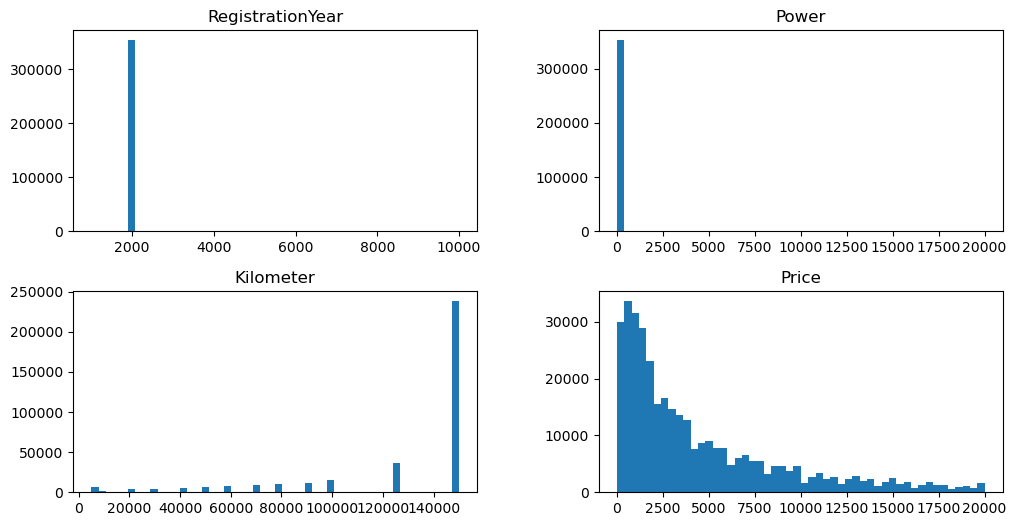

```python
autos[num_cols+target_col].hist(bins=50, figsize=(12, 6), grid=False);
```

В колонке целевого признака также обнаружены аномалии около 0:

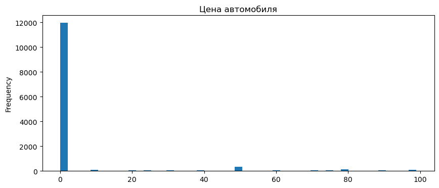

```python
autos.loc[autos['Price'] < 100, 'Price'].plot.hist(bins=47, figsize=(10, 4), title=f'{ru_name["Price"]}');
```

Исправляю аномальные значения признаков `Price`, `RegistrationYear` и `Power`:

Удаляю строки с околонулевыми значениями целевого признака:

```python
autos = autos[autos['Price'] > 2]
```

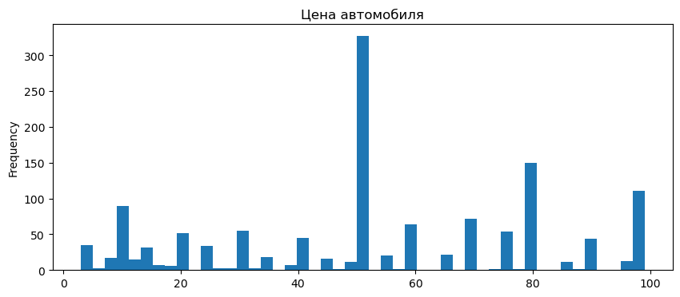

```python
autos.loc[autos['Price'] < 100, 'Price'].plot.hist(bins=47, figsize=(10, 4), title=f'{ru_name["Price"]}');
```

Корректирую признак `RegistrationYear`. Данные представлены по апрель 2016-го года, позже рассматривать не имеет смысла.

```python
autos = autos[autos['RegistrationYear'] <= 2016]
```

Посчитаю 3$\sigma$ квантиль (99,7% распределения):

```python
sigma_3_reg = autos['RegistrationYear'].quantile(1-0.997)
sigma_3_reg
```

```
1968.0
```

Слева фильтрую по 3$\sigma$ квантилю:

```python
autos = autos[autos['RegistrationYear'] >= sigma_3_reg]
```

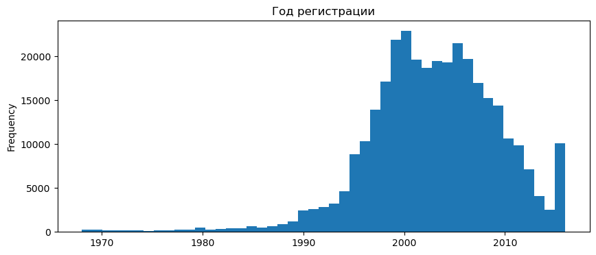

```python
autos['RegistrationYear'].plot.hist(bins=47, figsize=(10, 4), title=f'{ru_name["RegistrationYear"]}');
```

Корректирую признак `Power`. Аномальные значения в 0 удаляю:

```python
autos = autos[autos['Power'] != 0]
```

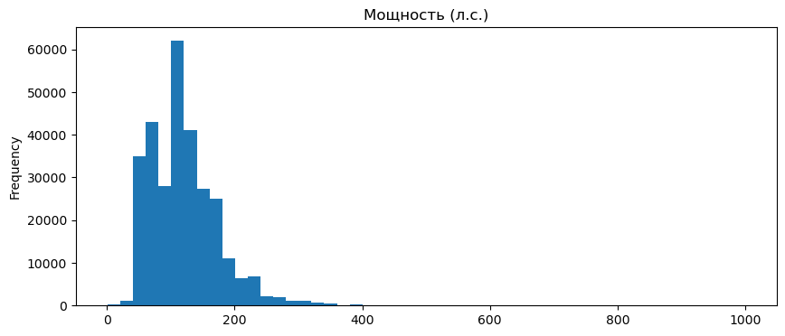

```python
autos.loc[autos['Power'] < 1000, 'Power'].plot.hist(bins=50, figsize=(10, 4), title=f'{ru_name["Power"]}');
```

Для коррекции распределения признака `Power` посчитаю $3\sigma$ квантиль (граница 99,7% распределения):

```python
sigma_3_pow = autos['Power'].quantile(0.997)
sigma_3_pow
```

```
367.0
```

Корректирую выбросы:

```python
autos = autos[autos['Power'] <= sigma_3_pow]
```

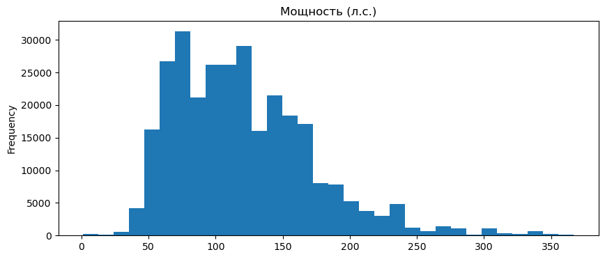

```python
autos['Power'].plot.hist(bins=32, figsize=(10, 4), title=f'{ru_name["Power"]}');
```

Распределение категориальных признаков `VehicleType`, `Gearbox`, `FuelType`, `Repaired`:

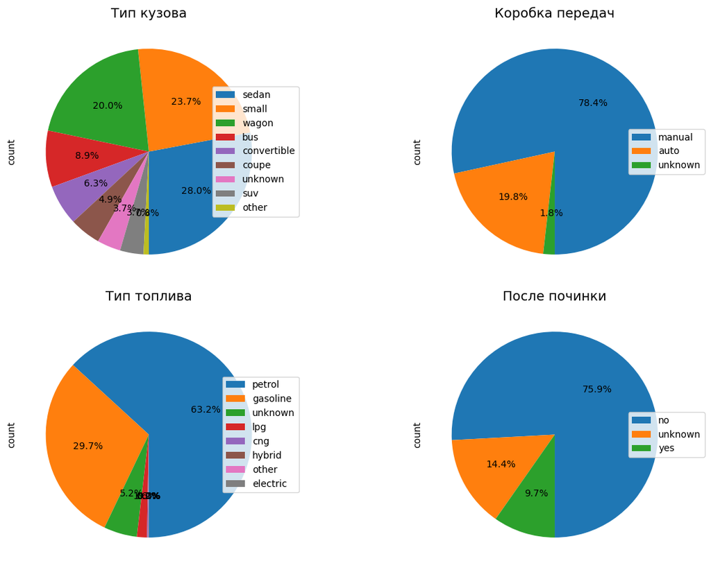

```python
fig, axes = plt.subplots(ncols=2, nrows=2, figsize=(12, 8))
axes = axes.flat
for i, col in enumerate(['VehicleType', 'Gearbox', 'FuelType', 'Repaired']):
    autos[col].fillna('unknown').value_counts().plot.pie(ax=axes[i], autopct='%1.1f%%', startangle=-90, labels=None,
                                       textprops={'fontsize': 10})
    axes[i].set_title(ru_name[col], fontsize=14)
    axes[i].legend(labels=autos[col].fillna('unknown').value_counts().index,
                   loc='center right', bbox_to_anchor=(1.1, .5), fontsize=10)
plt.subplots_adjust(left=0, bottom=0, right=1, top=1, wspace=0, hspace=0.1)
```

`gasoline` и `petrol` - одно и то же, провожу замену:

```python
autos['FuelType'] = autos['FuelType'].replace('petrol', 'gasoline')
```

Распределение категориальных признаков `Model`, `Brand`:

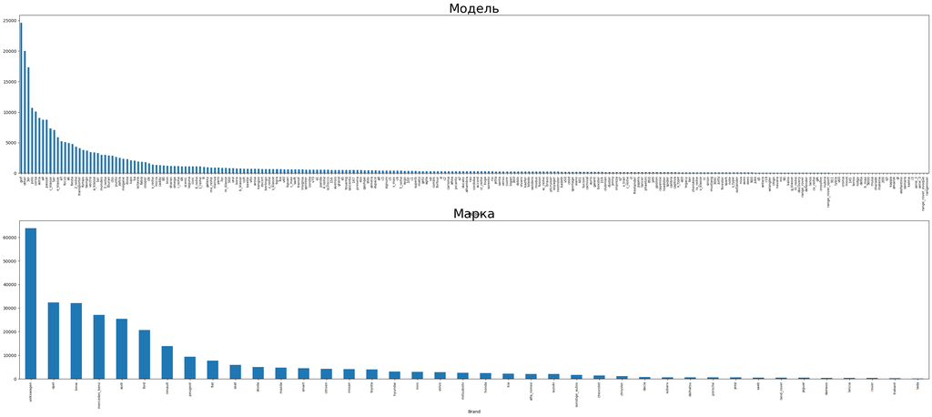

```python
fig, axes = plt.subplots(ncols=1, nrows=2, figsize=(30, 12))
axes = axes.flat
for i, col in enumerate(['Model', 'Brand']):
    autos[col].value_counts().plot.bar(ax=axes[i])
    axes[i].set_title(ru_name[col], fontsize=30)
    plt.setp(axes[i].get_xticklabels(), fontsize=8, rotation='vertical')
plt.subplots_adjust(left=0, bottom=0, right=1, top=1, wspace=0.1, hspace=0.3)
```

Аномалий в признаках `Model` и `Brand` не выявлено.

Корреляции и графики попарного разброса числовых переменных:

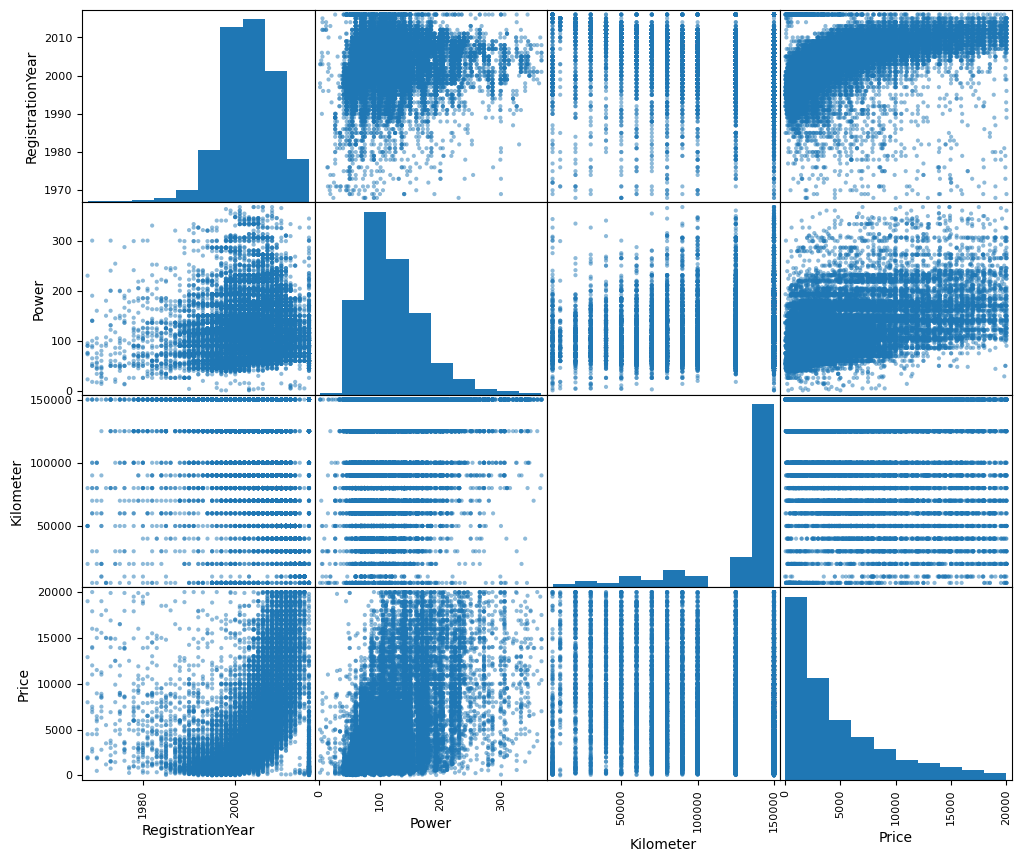

```python
pd.plotting.scatter_matrix(autos[num_cols+target_col].sample(frac=0.1), figsize=(12, 10));
```

```python
autos[num_cols+target_col].corr().style.background_gradient(cmap='Blues')
```

|  | RegistrationYear | Power | Kilometer | Price |
| --- | --- | --- | --- | --- |
| RegistrationYear | 1.000000 | 0.138791 | -0.318244 | 0.516570 |
| Power | 0.138791 | 1.000000 | 0.108183 | 0.509126 |
| Kilometer | -0.318244 | 0.108183 | 1.000000 | -0.389949 |
| Price | 0.516570 | 0.509126 | -0.389949 | 1.000000 |

Мультиколлинеарности не выявлено. Есть средняя линейная связь между парами признаков (`Price`, `RegistrationYear`) и (`Price`, `Power`)

### Предобработка данных

Функция заполения пробелов по типичным значениям в группе (`Brand`,`Model`)

```python
methods = {'median': 'median',
           'mean': 'mean',
           'mode': lambda x: x.mode().iloc[0]}

def fill_column_na(df, col, method):
    print(f'Пропусков в колонке {col} до заполнения: {df[col].isna().mean().round(4) * 100:.2f}%')
    df[col] = df[col].fillna(
    df.groupby(['Brand','Model'])[col].transform(methods[method]))
    print(f'Пропусков в колонке {col} после заполнения: {df[col].isna().mean().round(4) * 100:.2f}%')
```

```python
nans = autos.apply([lambda x: x.isna().sum(), lambda x: x.isna().mean().round(4) * 100]).transpose()
nans.columns = ['Пропуски', '%']
nans.sort_values(by='%', ascending=False)
```

|  | Пропуски | % |
| --- | --- | --- |
| Repaired | 42523.0 | 14.42 |
| FuelType | 15372.0 | 5.21 |
| Model | 10924.0 | 3.71 |
| VehicleType | 10885.0 | 3.69 |
| Gearbox | 5295.0 | 1.80 |
| Price | 0.0 | 0.00 |
| RegistrationYear | 0.0 | 0.00 |
| Power | 0.0 | 0.00 |
| Kilometer | 0.0 | 0.00 |
| Brand | 0.0 | 0.00 |

Пропуски найдены в колонках `Repaired`, `VehicleType`, `FuelType`, `Gearbox`, `Model`. Удаляю строки, в которых отсутствуют данные во всех из этих колонках сразу:

```python
autos = autos[~autos[['Repaired', 'VehicleType', 'FuelType', 'Gearbox', 'Model']].isna().all(axis=1)]
```

В результате тестирования различных стратегий заполнения пробелов наилучших результатов моделей по RMSE удалось достичь при удалении пропусков в колонках `VehicleType`, `FuelType`, `Repaired`. Заполнив пробелы модой в колонке `Gearbox`.

```python
# fill_column_na(autos, 'VehicleType', 'mode')
# fill_column_na(autos, 'FuelType', 'mode')
# autos['Repaired'] = autos['Repaired'].fillna('unknown')

fill_column_na(autos, 'Gearbox', 'mode')
```

```
Пропусков в колонке Gearbox до заполнения: 1.76%
Пропусков в колонке Gearbox после заполнения: 0.18%
```

Удаляю оставшиеся пробелы:

```python
autos = autos.dropna().reset_index(drop=True)
```

```python
nans = autos.apply([lambda x: x.isna().sum(), lambda x: x.isna().mean().round(4) * 100]).transpose()
nans.columns = ['Пропуски', '%']
nans.sort_values(by='%', ascending=False)
```

|  | Пропуски | % |
| --- | --- | --- |
| Price | 0.0 | 0.0 |
| VehicleType | 0.0 | 0.0 |
| RegistrationYear | 0.0 | 0.0 |
| Gearbox | 0.0 | 0.0 |
| Power | 0.0 | 0.0 |
| Model | 0.0 | 0.0 |
| Kilometer | 0.0 | 0.0 |
| FuelType | 0.0 | 0.0 |
| Brand | 0.0 | 0.0 |
| Repaired | 0.0 | 0.0 |

### Выводы, подготовка данных:

- Файл `autos.csv` был загружен в датафрейм `autos`, файл содержит 354369 строк и 16 признаков, из которых было удалено 4 строки (дубликаты) и 6 признаков (`NumberOfPictures`,`DateCrawled`, `DateCreated`, `LastSeen`, `PostalCode`, `RegistrationMonth` - либо не несли полезной информации, либо дублировали её)
- Анализ стандартных статистик и гистограмм числовых признаков выявил аномальные значения признаков `Power` и `RegistrationYear`, которые были скорректированы. Анализ круговых диаграмм категориальных признаков выявил дублирование характеристик `gasoline` и `petrol`, которое было устранено.
- Мультиколлинеарности числовых признаков не выявлено. Выявлена средняя линейная взаимосвязь пар признаков (`Price`, `RegistrationYear`) и (`Price`, `Power`)
- В результате тестирования различных стратегий заполнения пробелов наилучших результатов моделей по RMSE удалось достичь при удалении пропусков в колонках `VehicleType`, `FuelType`, `Repaired`. Заполнив пробелы модой в колонке `Gearbox`.

## Обучение моделей

Функции разделения (и кодировки) данных; тренировки моделей; подбора гиперпараметров:

```python
def split_data(dataframe, scaled=True, poly=False, ohe=False, ordinal=False,
               val_test_size=0.4, random_state=12, poly_degree=2):
    '''
    Фукнция делит датафрейм на 3 выборки: тренировочную, валидационную и тестовую;
    а также опционально применяет One-Hot и Ordinal кодирование данных
    '''
    for c in cat_cols:
        dataframe[c] = dataframe[c].astype('category')

    features = dataframe.drop(target_col, axis=1)
    target = dataframe[target_col]

    features_train, features_valtest, target_train, target_valtest = train_test_split(
        features, target, test_size=val_test_size, random_state=random_state)

    features_val, features_test, target_val, target_test = train_test_split(
        features_valtest, target_valtest, test_size=0.5, random_state=random_state)

    fts = [features_train, features_val, features_test]
    tgs = [target_train.values.ravel(), target_val.values.ravel(), target_test.values.ravel()]


    if scaled:       # нормализация
        scaler = StandardScaler()
        scaler.fit(fts[0][num_cols])
        for f in range(len(fts)):
            scaled = pd.DataFrame(scaler.transform(fts[f][num_cols]), columns=fts[f][num_cols].columns, index=fts[f].index)
            fts[f] = pd.concat([fts[f].drop(num_cols, axis=1), scaled], axis=1)
            for n in num_cols:
                fts[f][n] = pd.to_numeric(fts[f][n], downcast='float')

    if poly:         # генерирование новых признаков из-за нелинейности некоторых парных диаграмм распределения
        encoder = PolynomialFeatures(degree=poly_degree)
        encoder.fit(fts[0][num_cols])
        for f in range(len(fts)):
            encoded_poly = pd.DataFrame(encoder.transform(fts[f][num_cols]),
                                  columns=encoder.get_feature_names_out(), index=fts[f].index)
            fts[f] = pd.concat([fts[f].drop(num_cols, axis=1), encoded_poly], axis=1)

    if ohe:          # One-Hot кодирование
        encoder = OneHotEncoder(drop='first', handle_unknown='ignore', dtype='int8')
        encoder.fit(fts[0][cat_cols])
        for f in range(len(fts)):
            encoded_ohe = pd.DataFrame(encoder.transform(fts[f][cat_cols]).toarray(),
                                         columns=encoder.get_feature_names_out(), index=fts[f].index)
            fts[f] = pd.concat([fts[f].drop(cat_cols, axis=1), encoded_ohe], axis=1)

    if ordinal:       # Порядковое кодирование
        encoder = OrdinalEncoder(handle_unknown='use_encoded_value', unknown_value=-1, dtype='int16')
        encoder.fit(fts[0][cat_cols])
        for f in range(len(fts)):
            encoded_ord = pd.DataFrame(encoder.transform(fts[f][cat_cols]),
                                         columns=fts[f][cat_cols].columns, index=fts[f].index)
            fts[f] = pd.concat([fts[f].drop(cat_cols, axis=1), encoded_ord], axis=1)

    return *fts, *tgs
```

```python
def train_model(model_name, params, features_train, features_test, target_train, target_test, **kwargs):
    '''Тренирует модель (fit), и предсказывает (predict)
    Возвращает натренированную модель, показатель качества предсказаний RMSE
    и время, затраченные на тренировку и предсказание
    '''
    model = model_name(**params, **kwargs)

    start_train = time()
    model.fit(features_train, target_train)
    stop_train = time()

    start_infer = time()
    pred_test = model.predict(features_test)
    stop_infer = time()

    rmse = mean_squared_error(pred_test, target_test) ** 0.5

    return model, rmse, stop_train - start_train, stop_infer - start_infer

def finetune(model_name, parameters, features, target, verbose=3, jobs=-1, **kwargs):
    '''Фукнция подбора гиперпараметров
    На вход принимает класс модели, решетку гиперпараметров для поиска, признаки и целевой признак
    Возвращает лучшую из натренерованных моделей, её гиперпараметры и её луший результат по метрике RMSE
    '''
    cv = RandomizedSearchCV(model_name(**kwargs), param_distributions=parameters,
                      scoring='neg_mean_squared_error', cv=3, refit=True, verbose=verbose, n_jobs=jobs)
    cv.fit(features, target)

    return cv.best_estimator_, cv.best_params_, np.sqrt(-cv.best_score_)

def print_cv_results(params, rmse):
    '''Выводит результаты кросс-валидации на экран'''
    print()
    print(f'Лучшие параметры модели: {params}')
    print(f'(train, CV) лучшее RMSE: {rmse:.2f}')
    print()
```

One-Hot кодирование категориальных признаков с нормализацией числовых:

```python
features_train_ohe, features_val_ohe, features_test_ohe, \
target_train_ohe, target_val_ohe, target_test_ohe = split_data(autos, ohe=True, poly=True, poly_degree=4)

features_train_ohe.head()
```

|  | 1 | RegistrationYear | Power | Kilometer | RegistrationYear^2 | RegistrationYear Power | RegistrationYear Kilometer | Power^2 | Power Kilometer | Kilometer^2 | ... | Brand_seat | Brand_skoda | Brand_smart | Brand_subaru | Brand_suzuki | Brand_toyota | Brand_trabant | Brand_volkswagen | Brand_volvo | Repaired_yes |
| --- | --- | --- | --- | --- | --- | --- | --- | --- | --- | --- | --- | --- | --- | --- | --- | --- | --- | --- | --- | --- | --- |
| 150712 | 1.0 | 0.311510 | 0.341571 | 0.621646 | 0.097038 | 0.106403 | 0.193649 | 0.116671 | 0.212336 | 0.386444 | ... | 0 | 0 | 0 | 0 | 0 | 0 | 0 | 1 | 0 | 1 |
| 61913 | 1.0 | -1.043701 | -0.138380 | 0.621646 | 1.089311 | 0.144427 | -0.648812 | 0.019149 | -0.086023 | 0.386444 | ... | 0 | 0 | 0 | 0 | 0 | 0 | 0 | 0 | 0 | 0 |
| 102568 | 1.0 | 0.142108 | -1.117480 | -0.727667 | 0.020195 | -0.158803 | -0.103408 | 1.248762 | 0.813154 | 0.529500 | ... | 0 | 0 | 0 | 0 | 0 | 0 | 0 | 1 | 0 | 0 |
| 110653 | 1.0 | -0.704898 | 1.359068 | 0.621646 | 0.496881 | -0.958005 | -0.438197 | 1.847066 | 0.844859 | 0.386444 | ... | 0 | 0 | 0 | 0 | 0 | 0 | 0 | 0 | 0 | 0 |
| 7866 | 1.0 | -0.366096 | -0.234370 | -0.727667 | 0.134026 | 0.085802 | 0.266396 | 0.054929 | 0.170543 | 0.529500 | ... | 0 | 0 | 0 | 0 | 0 | 0 | 0 | 0 | 0 | 0 |

5 rows × 334 columns

Порядковое кодировани признаков с нормализацией числовых:

```python
features_train_ord, features_val_ord, features_test_ord, \
target_train_ord, target_val_ord, target_test_ord = split_data(autos, ordinal=True)

features_train_ord.head()
```

|  | RegistrationYear | Power | Kilometer | VehicleType | Gearbox | Model | FuelType | Brand | Repaired |
| --- | --- | --- | --- | --- | --- | --- | --- | --- | --- |
| 150712 | 0.311510 | 0.341571 | 0.621646 | 0 | 0 | 220 | 2 | 37 | 1 |
| 61913 | -1.043701 | -0.138380 | 0.621646 | 7 | 1 | 11 | 2 | 2 | 0 |
| 102568 | 0.142108 | -1.117480 | -0.727667 | 5 | 1 | 173 | 2 | 37 | 0 |
| 110653 | -0.704898 | 1.359068 | 0.621646 | 4 | 0 | 15 | 2 | 2 | 0 |
| 7866 | -0.366096 | -0.234370 | -0.727667 | 1 | 1 | 158 | 2 | 19 | 0 |

Простое разделение признаков с нормализацией числовых:

```python
features_train, features_val, features_test, target_train, target_val, target_test = split_data(autos)

features_train.head()
```

|  | VehicleType | Gearbox | Model | FuelType | Brand | Repaired | RegistrationYear | Power | Kilometer |
| --- | --- | --- | --- | --- | --- | --- | --- | --- | --- |
| 150712 | bus | auto | touran | gasoline | volkswagen | yes | 0.311510 | 0.341571 | 0.621646 |
| 61913 | wagon | manual | 3er | gasoline | bmw | no | -1.043701 | -0.138380 | 0.621646 |
| 102568 | small | manual | polo | gasoline | volkswagen | no | 0.142108 | -1.117480 | -0.727667 |
| 110653 | sedan | auto | 5er | gasoline | bmw | no | -0.704898 | 1.359068 | 0.621646 |
| 7866 | convertible | manual | mx_reihe | gasoline | mazda | no | -0.366096 | -0.234370 | -0.727667 |

Удаляю ненужные переменные:

```python
del target_train_ohe, target_val_ohe, target_test_ohe, target_train_ord, target_val_ord, target_test_ord

target_train_ohe = target_train_ord = target_train
target_val_ohe = target_val_ord = target_val
target_test_ohe = target_test_ord = target_test
```

### Линейная регрессия

```python
%%time

params = {}
lr_best_model, lr_best_params, lr_best_rmse = finetune(LinearRegression, params, features_train_ohe, target_train_ohe)
print_cv_results(lr_best_params, lr_best_rmse)
```

```
Fitting 3 folds for each of 1 candidates, totalling 3 fits
```

```
Лучшие параметры модели: {}
(train, CV) лучшее RMSE: 1835.93

CPU times: user 5.68 s, sys: 6.11 s, total: 11.8 s
Wall time: 18.7 s
```

### Случайный лес

```python
%%time

params = {
    'n_estimators' : [115, 120],
    'min_samples_leaf': [2, 3],
    'min_samples_split': [6, 7],
}

rf_best_model, rf_best_params, rf_best_rmse = finetune(RandomForestRegressor, params,
                                                        features_train_ord, target_train_ord, random_state=42)
print_cv_results(rf_best_params, rf_best_rmse)
```

```
Fitting 3 folds for each of 8 candidates, totalling 24 fits
```

```
Лучшие параметры модели: {'n_estimators': 120, 'min_samples_split': 7, 'min_samples_leaf': 2}
(train, CV) лучшее RMSE: 1611.78

CPU times: user 59.2 s, sys: 905 ms, total: 1min
Wall time: 8min 2s
```

### Градиентный бустинг

#### CatBoost

```python
%%time

params = {
    'learning_rate': [0.4, 0.45],
    'iterations': [1050, 1150],
    'l2_leaf_reg': [3]

}

cb_best_model, cb_best_params, cb_best_rmse = finetune(CatBoostRegressor, params,
                                       features_train, target_train, cat_features=cat_cols, random_state=42)
print_cv_results(cb_best_params, cb_best_rmse)
```

```
Fitting 3 folds for each of 4 candidates, totalling 12 fits
```

[output not shown]

[output cut: 4042 more lines]

[output not shown]

[output not shown]

[output cut: 12155 more lines]

[output not shown]

[output not shown]

[output cut: 89 more lines]

[output not shown]

[output not shown]

[output cut: 235 more lines]

[output not shown]

[output not shown]

[output cut: 4033 more lines]

[output not shown]

[output not shown]

[output cut: 379 more lines]

[output not shown]

[output not shown]

[output cut: 2159 more lines]

[output not shown]

[output not shown]

[output cut: 1101 more lines]

```
1141:	learn: 1355.8816749	total: 1m	remaining: 420ms
1142:	learn: 1355.7737982	total: 1m	remaining: 368ms
1143:	learn: 1355.7388088	total: 1m	remaining: 315ms
1144:	learn: 1355.6386719	total: 1m	remaining: 263ms
1145:	learn: 1355.5856277	total: 1m	remaining: 210ms
1146:	learn: 1355.4980804	total: 1m	remaining: 158ms
1147:	learn: 1355.4918156	total: 1m	remaining: 105ms
1148:	learn: 1355.4199087	total: 1m	remaining: 52.6ms
1149:	learn: 1355.3410632	total: 1m	remaining: 0us

Лучшие параметры модели: {'learning_rate': 0.45, 'l2_leaf_reg': 3, 'iterations': 1150}
(train, CV) лучшее RMSE: 1570.19

CPU times: user 2min 47s, sys: 4.55 s, total: 2min 51s
Wall time: 14min 8s
```

#### LightGBM

```python
%%time

params = {'learning_rate': [0.07, 0.08, 0.09],
          'num_leaves':[462, 464, 466],
          'max_bin': [128, 256, 512, 1024]
}

lgbm_best_model, lgbm_best_params, lgbm_best_rmse = finetune(LGBMRegressor, params,
                                       features_train, target_train, random_state=42)

print_cv_results(lgbm_best_params, lgbm_best_rmse)
```

[output not shown]

[output cut: 41 more lines]

[output not shown]

```python
pd.set_option('display.max_colwidth', None)
best_params = pd.DataFrame({'Модель': ['Линейная регрессия', 'Случайный лес', 'CatBoost', 'LightGBM'],
              'CV RMSE': [round(x, 2) for x in  [lr_best_rmse, rf_best_rmse, cb_best_rmse, lgbm_best_rmse]],
              'best params': [lr_best_params, rf_best_params, cb_best_params, lgbm_best_params]
             }).set_index('Модель').sort_values(by='CV RMSE')
```

### Выводы, обучение моделей:

- Методом кросс-валидации были обучены модели линейной регрессии, случайного леса, градиентного бустинга (CatBoost и LightGBM), были получены следующие результаты:

```python
best_params
```

| Модель | CV RMSE | best params |
| --- | --- | --- |
| LightGBM | 1526.29 | {'num_leaves': 466, 'max_bin': 1024, 'learning_rate': 0.08} |
| CatBoost | 1570.19 | {'learning_rate': 0.45, 'l2_leaf_reg': 3, 'iterations': 1150} |
| Случайный лес | 1611.78 | {'n_estimators': 120, 'min_samples_split': 7, 'min_samples_leaf': 2} |
| Линейная регрессия | 1835.93 | {} |

Подобранные параметры будут использоваться дальше для анализа моделей по критериям

- качества предсказания;
- скорости предсказания;
- времени обучения.

## Анализ моделей

Функция вывода результатов модели:

```python
def print_an_results(val_rmse, train_time, infer_time):
    '''Выводит оценки времени и качества моделей на экран'''

    print()
    print(f'(val) итоговое RMSE: {val_rmse:.2f}')
    print(f'Обучение заняло {train_time:.2f} сек.')
    print(f'Предсказание заняло {infer_time:.2f} сек.')
    print()
```

### Линейная регрессия

```python
lr2_model, lr2_val_rmse, lr2_train_time, lr2_infer_time = train_model(
    LinearRegression, lr_best_params, features_train_ohe, features_val_ohe, target_train_ohe, target_val_ohe)

print_an_results(lr2_val_rmse, lr2_train_time, lr2_infer_time)
```

```
(val) итоговое RMSE: 1822.36
Обучение заняло 5.46 сек.
Предсказание заняло 0.60 сек.
```

### Случайный лес

```python
rf2_model, rf2_val_rmse, rf2_train_time, rf2_infer_time = train_model(
    RandomForestRegressor, rf_best_params, features_train_ord, features_val_ord, target_train_ord, target_val_ord)

print_an_results(rf2_val_rmse, rf2_train_time, rf2_infer_time)
```

```
(val) итоговое RMSE: 1561.42
Обучение заняло 56.07 сек.
Предсказание заняло 2.37 сек.
```

### CatBoost

```python
cb2_model, cb2_val_rmse, cb2_train_time, cb2_infer_time = train_model(
CatBoostRegressor, cb_best_params, features_train, features_val, target_train, target_val, cat_features=cat_cols)

print_an_results(cb2_val_rmse, cb2_train_time, cb2_infer_time)
```

[output not shown]

[output cut: 1947 more lines]

[output not shown]

### LightGBM

```python
lgbm2_model, lgbm2_val_rmse, lgbm2_train_time, lgbm2_infer_time = train_model(
LGBMRegressor, lgbm_best_params, features_train, features_val, target_train, target_val)

print_an_results(lgbm2_val_rmse, lgbm2_train_time, lgbm2_infer_time)
```

```
(val) итоговое RMSE: 1478.52
Обучение заняло 13.55 сек.
Предсказание заняло 0.65 сек.
```

Итоговая таблица с показателями модели. Чтобы получить рейтинг модели понадобится нормализовать значения в таблице и определиться с весами (что клиенту важнее).

```python
final_stats = pd.DataFrame({'Модель': ['Линейная регрессия', 'Случайный лес', 'CatBoost', 'LightGBM'],
              '(val) RMSE': [round(x, 2) for x in [lr2_val_rmse, rf2_val_rmse, cb2_val_rmse, lgbm2_val_rmse]],
              'Training time': [round(x, 2) for x in [lr2_train_time, rf2_train_time, cb2_train_time, lgbm2_train_time]],
              'Inference time': [round(x, 2) for x in [lr2_infer_time, rf2_infer_time, cb2_infer_time, lgbm2_infer_time]]
             }).set_index('Модель')
final_stats
```

| Модель | (val) RMSE | Training time | Inference time |
| --- | --- | --- | --- |
| Линейная регрессия | 1822.36 | 5.46 | 0.60 |
| Случайный лес | 1561.42 | 56.07 | 2.37 |
| CatBoost | 1531.66 | 106.49 | 0.73 |
| LightGBM | 1478.52 | 13.55 | 0.65 |

### Формирование рейтинга моделей

Все полученные значения моделей находятся в обратных метриках (чем меньше, тем лучше), чтобы перейти к рейтингу, нужно перейти к прямым метрикам, для этого домножаю на -1.

Также, чтобы значения были сопоставимы, нормализую все колонки:

```python
normalized_stats = (final_stats * -1).apply(lambda x: (x - x.mean()) / x.std())
normalized_stats
```

| Модель | (val) RMSE | Training time | Inference time |
| --- | --- | --- | --- |
| Линейная регрессия | -1.461912 | 0.860842 | 0.569061 |
| Случайный лес | 0.242074 | -0.230179 | -1.497068 |
| CatBoost | 0.436412 | -1.317105 | 0.417311 |
| LightGBM | 0.783426 | 0.686442 | 0.510696 |

Привожу значения к рейтингу от 0 до 10 через сигмоиду:

```python
def sigmoid(x):
    return 1/(1 + np.exp(-x))

ratings = normalized_stats.apply(sigmoid) * 10
ratings
```

| Модель | (val) RMSE | Training time | Inference time |
| --- | --- | --- | --- |
| Линейная регрессия | 1.881750 | 7.028365 | 6.385464 |
| Случайный лес | 5.602247 | 4.427079 | 1.828633 |
| CatBoost | 6.074038 | 2.113004 | 6.028397 |
| LightGBM | 6.864181 | 6.651751 | 6.249695 |

Допустим, клиент определил следующий приоритет характеристик у моделей: важнее всего скорость предсказаний, затем точность предсказаний, затем время обучения. Для примера, возьму такие веса: скорость - 0,5; качество - 0,3; время - 0,2:

```python
weights = pd.DataFrame({'': 'веса',
                        '(val) RMSE': [0.3],
                        'Training time': [0.2],
                        'Inference time':[0.5]}).set_index('')
weights
```

|  | (val) RMSE | Training time | Inference time |
| --- | --- | --- | --- |
| веса | 0.3 | 0.2 | 0.5 |

Перемножением матрицы рейтингов на веса можно получить итоговый рейтинг модели:

```python
model_rating = np.dot(ratings.values, weights.values.T)
final_rating = pd.DataFrame(model_rating.ravel().round(2), columns=['Rating'], index=final_stats.index).sort_values(by='Rating', ascending=False)
final_rating
```

| Модель | Rating |
| --- | --- |
| LightGBM | 6.51 |
| CatBoost | 5.26 |
| Линейная регрессия | 5.16 |
| Случайный лес | 3.48 |

### Выводы, анализ моделей

- В ходе анализа моделей машинного обучения (линейной регрессии, случайного леса, CatBoost и LightGBM) были найдены их временные и качественные харакетристики, которые были затем сведены в матрицу и приведены к рейтинговому виду.
- Был сформулирован механизм получения рейтинга модели на основе вектора весов, отражающего предпочтения клиента, и матрицы рейтингов
- При векторе предпочтений [скорость - 0,5; качество - 0,3; время - 0,2] итоговый рейтинг моделей, проходивших обучение и анализ, выглядит так:

```python
final_rating
```

| Модель | Rating |
| --- | --- |
| LightGBM | 6.51 |
| CatBoost | 5.26 |
| Линейная регрессия | 5.16 |
| Случайный лес | 3.48 |

- На основе полученного рейтинга клиенту можно рекомендовать следующую модель:

```python
best_model = final_rating.index[0]
best_model
```

```
'LightGBM'
```

## Тестирование лучшей модели

```python
models = {'LightGBM': [lgbm2_model, features_test, target_test],
          'CatBoost': [cb2_model, features_test, target_test],
          'Линейная регрессия': [lr2_model, features_test_ohe, target_test_ohe],
          'Случайный лес': [rf2_model, features_test_ord, target_test_ord]}
```

```python
pred_test = models[best_model][0].predict(models[best_model][1])
final_test_rmse = mean_squared_error(models[best_model][2], pred_test) ** 0.5

# print(f'(test) RMSE модели {best_model}: {final_test_rmse:.2f}')
print(f'Итоговый показатель RMSE модели {best_model} на тестовых данных составил €{final_test_rmse:.2f}')
```

```
Итоговый показатель RMSE модели LightGBM на тестовых данных составил €1494.42
```

## Итоговый вывод:

- С целью выявить лучшую модель по нескольким критериям были построены и протестированы несколько моделей машинного обучения: Линейная регрессия, Случайный лес, Градиентный бустинг (CatBoost и LightGBM).
- В результате по критериям качества предсказания (`(val) RMSE`); скорости предсказания (`Inference time`); времени обучения (`Training time`) была сведена рейтинговая таблица моделей, по которой клиент может посчитать рейтинг нужной ему модели сообразно весам, которые он присвоит критериям, то есть клиенту был предоставлен механизм оценки обученных моделей на основе его предпочтений.
- Для примера были выбраны такие веса: скорость предсказания - 0,5; качество предсказаний - 0,3; время обучения - 0,2. Это дало следующий рейтинг моделей:

```python
final_table = pd.concat([final_stats, final_rating], axis=1).sort_values(by='Rating', ascending=False)
final_table
```

| Модель | (val) RMSE | Training time | Inference time | Rating |
| --- | --- | --- | --- | --- |
| LightGBM | 1478.52 | 13.55 | 0.65 | 6.51 |
| CatBoost | 1531.66 | 106.49 | 0.73 | 5.26 |
| Линейная регрессия | 1822.36 | 5.46 | 0.60 | 5.16 |
| Случайный лес | 1561.42 | 56.07 | 2.37 | 3.48 |

- Клиенту, чьи предпочтения описываются таким же вектором весов, предлагается для задачи определения стоимости автомобиля по историческим данным выбрать модель с наивысшим рейтингом:

```python
best_model
```

```
'LightGBM'
```

[output not shown]

[output cut: 157 more lines]

[output not shown]